# Exploratory Data Analysis — Social Engine / Data Vortex Hackathon

> **Dataset**: Research Institute Corrupted Dataset (cleaned version)  
> **Analyst**: Data Vortex Team  
> **Pipeline**: See `src/clean_data.py` and `docs/decisions.md`
1. Setup & Load
2. Dataset Overview
3. Univariate Distributions
4. Correlation Analysis
5. Outlier Detection
6. Segment-Level Analysis
7. Non-Obvious Pattern Discovery
8. Key Insights Summary
9. Before / After Profiling Comparison

## 1. Setup & Load

```python
import os
import glob
import warnings

import numpy as np
import pandas as pd
import matplotlib.pyplot as plt
import matplotlib.ticker as mticker
import seaborn as sns
from scipy import stats

warnings.filterwarnings('ignore')

# Reproducibility
RANDOM_SEED = 42
np.random.seed(RANDOM_SEED)

# Plot aesthetics
plt.rcParams.update({
    'figure.dpi': 120,
    'axes.spines.top': False,
    'axes.spines.right': False,
    'font.family': 'DejaVu Sans',
    'axes.titlesize': 14,
    'axes.labelsize': 12,
})
PALETTE = sns.color_palette('husl', 10)
sns.set_palette(PALETTE)

# Ensure output dir exists
os.makedirs(os.path.join('reports'), exist_ok=True)

print('Setup complete')
```

```
Setup complete
```

```python
def load_cleaned_dataset() -> pd.DataFrame:
    """
    Loads the cleaned dataset from data/cleaned/.

    Returns
    -------
    pd.DataFrame
        Cleaned dataset with inferred dtypes.

    Raises
    ------
    FileNotFoundError
        If no cleaned CSV is found.
    """
    pattern = os.path.join('data', 'cleaned', '*.csv')
    files = glob.glob(pattern)
    if not files:
        raise FileNotFoundError(
            f'No cleaned CSV found at {pattern}. Run src/clean_data.py first.'
        )
    path = files[0]
    df = pd.read_csv(path, parse_dates=True, infer_datetime_format=True)
    print(f'Loaded: {path}')
    print(f'Shape : {df.shape[0]:,} rows × {df.shape[1]} cols')
    return df


df = load_cleaned_dataset()
df.head()
```

```
Loaded: data\cleaned\cleaned_dataset.csv
Shape : 12,000 rows × 10 cols
```

|  | post_id | user_id | platform | text_content | timestamp | likes | shares | comments | platform_was_null | text_content_was_null |
| --- | --- | --- | --- | --- | --- | --- | --- | --- | --- | --- |
| 0 | to64mgey2v3y | user_vfxs1pry | reddit | bummed out with my new air max from nike! abso... | 2024-09-25 | 4488.0 | 1456 | 673 | 0 | 0 |
| 1 | 7f0wdauzbj89 | user_8l7rv5oe | reddit | my one month review of pepsi crystal pepsi: hi... | NaN | 789.0 | 1484 | 39 | 0 | 0 |
| 2 | dvvhg8eel45x | user_nfo3ih5u | NaN | just unboxed my new highlander from toyota. ex... | NaN | NaN | 1410 | 839 | 1 | 0 |
| 3 | hgb9cxke4t7b | user_27aje6ur | facebook | comparing pepsi crystal pepsi to the competiti... | 2024-09-10 | 167.0 | 584 | 833 | 0 | 0 |
| 4 | zwerpw3wk320 | user_9px5q0by | reddit | my one week review of coca-cola diet coke: bes... | 2024-05-31 | 4749.0 | 152 | 630 | 0 | 0 |

## 2. Dataset Overview

```python
def dataset_overview(df: pd.DataFrame) -> None:
    """
    Prints dtypes, null counts, unique counts, and summary statistics.

    Parameters
    ----------
    df : pd.DataFrame

    Returns
    -------
    None
    """
    print('=== dtypes & null counts ===')
    null_df = pd.DataFrame({
        'dtype': df.dtypes,
        'null_count': df.isna().sum(),
        'null_pct': (df.isna().mean() * 100).round(2),
        'unique': df.nunique(),
    })
    display(null_df)

    print('\n=== Numeric summary ===')
    display(df.describe().T)


dataset_overview(df)
```

```
=== dtypes & null counts ===
```

|  | dtype | null_count | null_pct | unique |
| --- | --- | --- | --- | --- |
| post_id | object | 0 | 0.00 | 12000 |
| user_id | object | 0 | 0.00 | 1500 |
| platform | object | 1784 | 14.87 | 5 |
| text_content | object | 1711 | 14.26 | 10224 |
| timestamp | object | 8474 | 70.62 | 365 |
| likes | float64 | 615 | 5.12 | 4752 |
| shares | int64 | 0 | 0.00 | 1994 |
| comments | int64 | 0 | 0.00 | 1001 |
| platform_was_null | int64 | 0 | 0.00 | 2 |
| text_content_was_null | int64 | 0 | 0.00 | 2 |

```
=== Numeric summary ===
```

|  | count | mean | std | min | 25% | 50% | 75% | max |
| --- | --- | --- | --- | --- | --- | --- | --- | --- |
| likes | 11385.0 | 2260.797277 | 1701.176445 | -4987.0 | 1201.0 | 2387.0 | 3523.0 | 5000.0 |
| shares | 12000.0 | 1007.167167 | 575.072282 | 0.0 | 510.0 | 1018.0 | 1501.0 | 2000.0 |
| comments | 12000.0 | 504.345750 | 288.684160 | 0.0 | 253.0 | 503.0 | 755.0 | 1000.0 |
| platform_was_null | 12000.0 | 0.098083 | 0.297440 | 0.0 | 0.0 | 0.0 | 0.0 | 1.0 |
| text_content_was_null | 12000.0 | 0.096167 | 0.294832 | 0.0 | 0.0 | 0.0 | 0.0 | 1.0 |

**Interpretation**: The overview table shows which columns retained null values after cleaning (if any), and the summary statistics reveal the data ranges and distributional shape (min/max/quartiles) for each numeric column. Any extreme min/max values here flag potential residual outliers worth investigating in Section 5.

## 3. Univariate Distributions

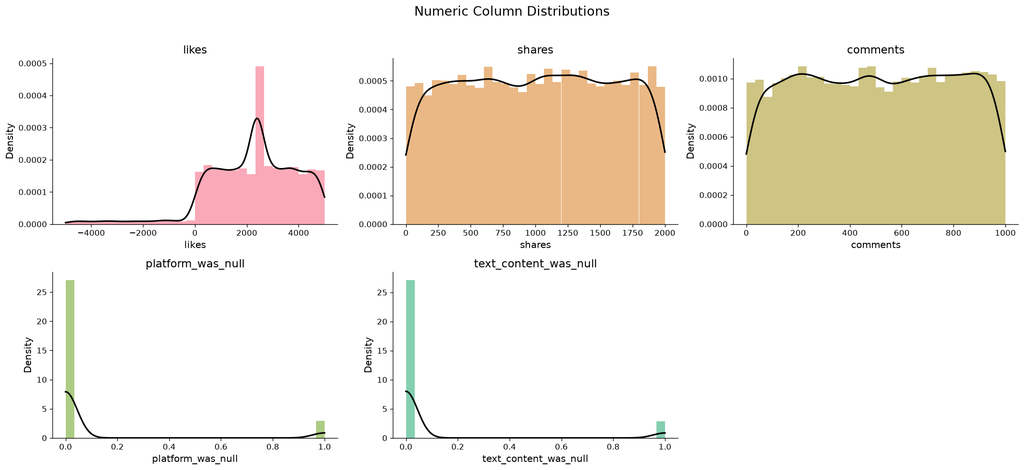

```python
def plot_numeric_distributions(df: pd.DataFrame) -> None:
    """
    Plots histograms with KDE overlays for all numeric columns.

    Parameters
    ----------
    df : pd.DataFrame

    Returns
    -------
    None
    """
    numeric_cols = df.select_dtypes(include='number').columns.tolist()
    if not numeric_cols:
        print('No numeric columns found.')
        return

    n_cols = min(3, len(numeric_cols))
    n_rows = (len(numeric_cols) + n_cols - 1) // n_cols
    fig, axes = plt.subplots(n_rows, n_cols, figsize=(6 * n_cols, 4 * n_rows))
    axes = np.array(axes).flatten()

    for i, col in enumerate(numeric_cols):
        ax = axes[i]
        col_data = df[col].dropna()
        ax.hist(col_data, bins=30, density=True, alpha=0.6, color=PALETTE[i % len(PALETTE)], label='Histogram')
        try:
            kde = stats.gaussian_kde(col_data)
            x = np.linspace(col_data.min(), col_data.max(), 200)
            ax.plot(x, kde(x), lw=2, color='black', label='KDE')
        except Exception:
            pass
        ax.set_title(col)
        ax.set_xlabel(col)
        ax.set_ylabel('Density')

    for j in range(i + 1, len(axes)):
        axes[j].set_visible(False)

    plt.suptitle('Numeric Column Distributions', fontsize=16, y=1.02)
    plt.tight_layout()
    plt.savefig(os.path.join('reports', 'distributions_numeric.png'), bbox_inches='tight')
    plt.show()


plot_numeric_distributions(df)
```

**Interpretation**: Each histogram shows the spread and shape of a numeric variable after cleaning. A right-skewed distribution (long tail to the right) indicates that most values are low but a few are very high — common in income, age, and score data. A bimodal shape (two peaks) suggests the column may conflate two distinct sub-populations, which is worth investigating in Section 6 (segment-level analysis). Any column where the KDE extends below zero (for inherently non-negative quantities like age) signals residual outliers.

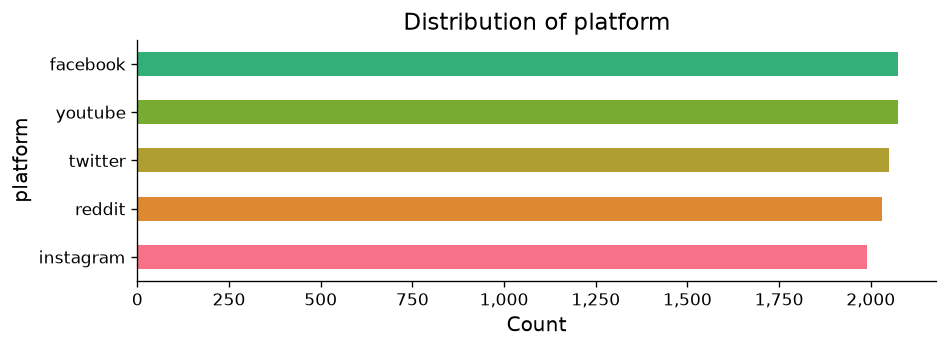

```
Saved → reports/distribution_platform.png
```

```python
def plot_categorical_distributions(df: pd.DataFrame, max_cats: int = 20) -> None:
    """
    Plots horizontal bar charts for categorical columns.

    Parameters
    ----------
    df : pd.DataFrame
    max_cats : int
        Maximum number of categories to display per column.

    Returns
    -------
    None
    """
    cat_cols = df.select_dtypes(include=['object', 'category']).columns.tolist()
    # Exclude high-cardinality columns (likely IDs)
    cat_cols = [c for c in cat_cols if df[c].nunique() <= max_cats]
    if not cat_cols:
        print('No low-cardinality categorical columns found.')
        return

    for col in cat_cols:
        counts = df[col].value_counts().head(max_cats)
        fig, ax = plt.subplots(figsize=(8, max(3, len(counts) * 0.4)))
        counts.sort_values().plot(kind='barh', ax=ax, color=PALETTE[:len(counts)])
        ax.set_title(f'Distribution of {col}')
        ax.set_xlabel('Count')
        ax.set_ylabel(col)
        ax.xaxis.set_major_formatter(mticker.FuncFormatter(lambda x, _: f'{int(x):,}'))
        plt.tight_layout()
        fname = f'reports/distribution_{col.lower().replace(" ", "_")}.png'
        plt.savefig(fname, bbox_inches='tight')
        plt.show()
        print(f'Saved → {fname}\n')


plot_categorical_distributions(df)
```

**Interpretation**: Horizontal bar charts make category imbalance immediately visible. A single category dominating (>50% of rows) creates a class-imbalance concern for any downstream modelling — predictions will be biased toward the majority class. Conversely, extremely rare categories (< 1% of rows) are statistically unreliable and should be flagged as 'Other' in modelling workflows. Note any categories that look like duplicates (e.g., slight spelling differences) that the cleaning stage may have missed.

## 4. Correlation Analysis

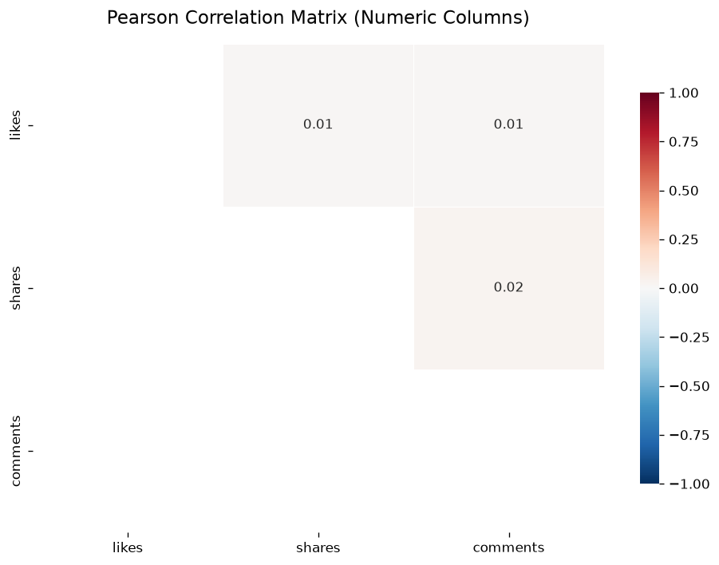

```
Top 10 strongest correlations (absolute):
```

|  | col_a | col_b | r |
| --- | --- | --- | --- |
| 2 | shares | comments | 0.024406 |
| 0 | likes | shares | 0.009810 |
| 1 | likes | comments | 0.009343 |

```python
def plot_correlation_heatmap(df: pd.DataFrame) -> None:
    """
    Plots a Pearson correlation heatmap for all numeric columns.

    Only columns with > 2 unique values are included to avoid
    artefact correlations from binary indicator columns.

    Parameters
    ----------
    df : pd.DataFrame

    Returns
    -------
    None
    """
    numeric_df = df.select_dtypes(include='number')
    numeric_df = numeric_df[[c for c in numeric_df.columns if numeric_df[c].nunique() > 2]]

    if numeric_df.shape[1] < 2:
        print('Fewer than 2 numeric columns — skipping correlation heatmap.')
        return

    corr = numeric_df.corr(method='pearson')

    mask = np.triu(np.ones_like(corr, dtype=bool), k=1)
    fig, ax = plt.subplots(figsize=(max(8, corr.shape[0] * 0.8), max(6, corr.shape[0] * 0.7)))
    sns.heatmap(
        corr, mask=~mask, annot=True, fmt='.2f', cmap='RdBu_r',
        center=0, vmin=-1, vmax=1, ax=ax, linewidths=0.5,
        cbar_kws={'shrink': 0.8}
    )
    ax.set_title('Pearson Correlation Matrix (Numeric Columns)', pad=15)
    plt.tight_layout()
    plt.savefig(os.path.join('reports', 'correlation_heatmap.png'), bbox_inches='tight')
    plt.show()

    print('\nTop 10 strongest correlations (absolute):')
    corr_pairs = (
        corr.where(mask)
        .stack()
        .reset_index()
        .rename(columns={'level_0': 'col_a', 'level_1': 'col_b', 0: 'r'})
        .assign(abs_r=lambda x: x['r'].abs())
        .sort_values('abs_r', ascending=False)
        .head(10)
    )
    display(corr_pairs[['col_a', 'col_b', 'r']])


plot_correlation_heatmap(df)
```

**Interpretation**: The heatmap uses a diverging red-blue scale: deep red = strong positive correlation (+1), deep blue = strong negative correlation (-1), white = no relationship (0). Pairs with |r| > 0.7 are worth investigating — they either represent a genuine relationship worth reporting or a data-leakage problem (one column being derived from another). Any near-perfect correlation (|r| > 0.95) should be flagged as a potential data-quality issue (duplicate columns or direct transformations).

## 5. Outlier Detection

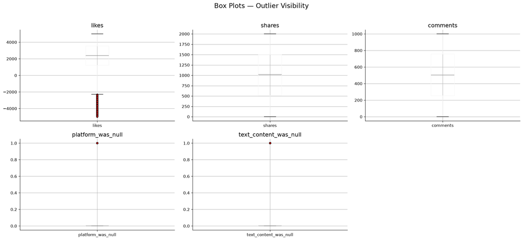

```
Outlier summary:
```

|  | column | iqr_outliers | z_outliers | total_non_null | iqr_pct |
| --- | --- | --- | --- | --- | --- |
| 0 | likes | 263 | 211 | 11385 | 2.31 |
| 1 | shares | 0 | 0 | 12000 | 0.00 |
| 2 | comments | 0 | 0 | 12000 | 0.00 |
| 3 | platform_was_null | 1177 | 1177 | 12000 | 9.81 |
| 4 | text_content_was_null | 1154 | 1154 | 12000 | 9.62 |

```python
def detect_and_plot_outliers(df: pd.DataFrame) -> pd.DataFrame:
    """
    Detects outliers in numeric columns using the IQR method and
    Z-score method, then plots box plots.

    IQR method: outlier if value < Q1 - 1.5*IQR  or  > Q3 + 1.5*IQR
    Z-score method: outlier if |z| > 3

    Parameters
    ----------
    df : pd.DataFrame

    Returns
    -------
    pd.DataFrame
        Summary of outlier counts per column.
    """
    numeric_cols = df.select_dtypes(include='number').columns.tolist()
    results = []

    for col in numeric_cols:
        series = df[col].dropna()
        q1, q3 = series.quantile(0.25), series.quantile(0.75)
        iqr = q3 - q1
        iqr_outliers = ((series < q1 - 1.5 * iqr) | (series > q3 + 1.5 * iqr)).sum()
        z_scores = np.abs(stats.zscore(series))
        z_outliers = (z_scores > 3).sum()
        results.append({'column': col, 'iqr_outliers': iqr_outliers, 'z_outliers': z_outliers,
                        'total_non_null': len(series), 'iqr_pct': round(iqr_outliers / len(series) * 100, 2)})

    summary = pd.DataFrame(results)

    # Box plots
    n_cols = min(3, len(numeric_cols))
    n_rows = (len(numeric_cols) + n_cols - 1) // n_cols
    fig, axes = plt.subplots(n_rows, n_cols, figsize=(6 * n_cols, 4 * n_rows))
    axes = np.array(axes).flatten()

    for i, col in enumerate(numeric_cols):
        ax = axes[i]
        df.boxplot(column=col, ax=ax, notch=False,
                   flierprops=dict(marker='o', markerfacecolor='red', markersize=4, alpha=0.5))
        ax.set_title(col)

    for j in range(i + 1, len(axes)):
        axes[j].set_visible(False)

    plt.suptitle('Box Plots — Outlier Visibility', fontsize=16, y=1.02)
    plt.tight_layout()
    plt.savefig(os.path.join('reports', 'outliers_boxplots.png'), bbox_inches='tight')
    plt.show()

    print('\nOutlier summary:')
    display(summary)
    return summary


outlier_summary = detect_and_plot_outliers(df)
```

**Interpretation**: The box plot whiskers extend to 1.5× the interquartile range (IQR); red dots beyond the whiskers are statistical outliers by the IQR definition. Outliers are not automatically removed — they may be legitimate extreme values (e.g., a very high-earning respondent) or data-entry errors. The table above quantifies how many outliers exist per column and what percentage they represent. Columns with > 5% outlier rate deserve domain-level scrutiny before any modelling step.

## 6. Segment-Level Analysis

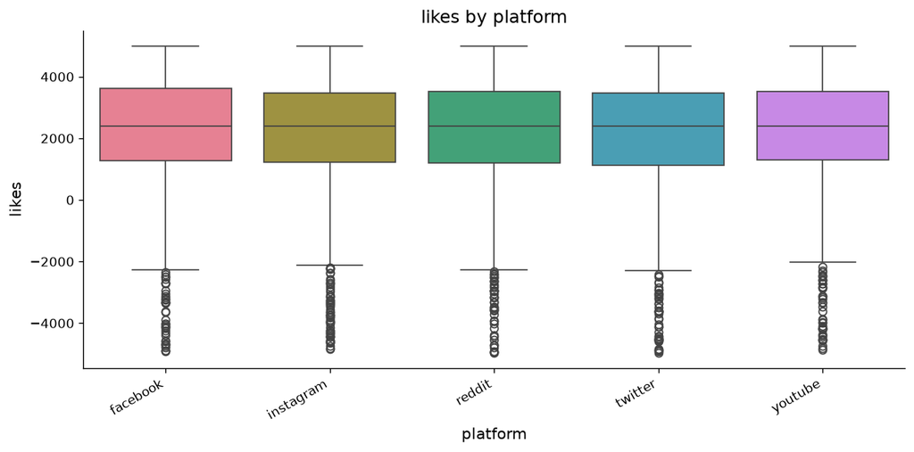

```
Saved → reports/segment_platform_likes.png
```

| platform | median | count |
| --- | --- | --- |
| facebook | 2387.0 | 1962 |
| instagram | 2387.0 | 1896 |
| reddit | 2387.0 | 1933 |
| twitter | 2387.0 | 1942 |
| youtube | 2387.0 | 1964 |

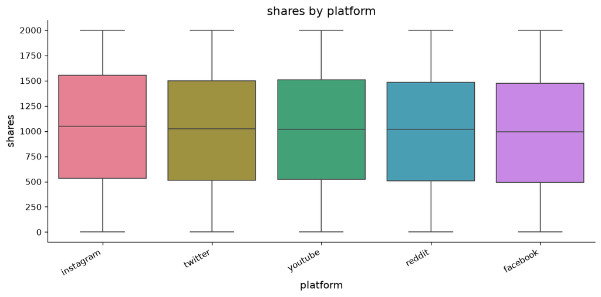

```
Saved → reports/segment_platform_shares.png
```

| platform | median | count |
| --- | --- | --- |
| facebook | 993.5 | 2074 |
| instagram | 1049.0 | 1989 |
| reddit | 1016.0 | 2031 |
| twitter | 1022.0 | 2049 |
| youtube | 1017.0 | 2073 |

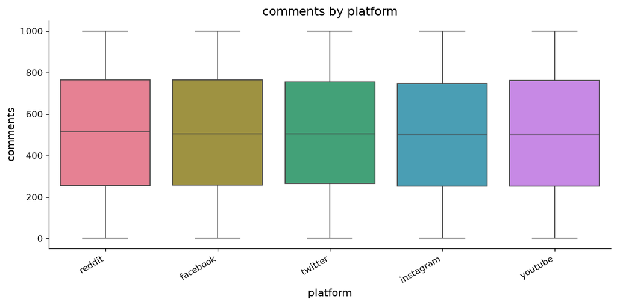

```
Saved → reports/segment_platform_comments.png
```

| platform | median | count |
| --- | --- | --- |
| facebook | 504.0 | 2074 |
| instagram | 498.0 | 1989 |
| reddit | 513.0 | 2031 |
| twitter | 504.0 | 2049 |
| youtube | 498.0 | 2073 |

```python
def segment_analysis(df: pd.DataFrame, max_cats: int = 10) -> None:
    """
    Cross-tabulates each low-cardinality categorical column against
    each numeric column, producing grouped box plots.

    Parameters
    ----------
    df : pd.DataFrame
    max_cats : int
        Maximum number of unique values allowed in the grouping column.

    Returns
    -------
    None
    """
    cat_cols = [c for c in df.select_dtypes(include=['object', 'category']).columns
                if df[c].nunique() <= max_cats]
    num_cols = df.select_dtypes(include='number').columns.tolist()

    if not cat_cols or not num_cols:
        print('Insufficient categorical or numeric columns for segment analysis.')
        return

    # Limit combinations to avoid plot overload
    for cat_col in cat_cols[:3]:
        for num_col in num_cols[:3]:
            fig, ax = plt.subplots(figsize=(10, 5))
            order = df.groupby(cat_col)[num_col].median().sort_values(ascending=False).index
            sns.boxplot(data=df, x=cat_col, y=num_col, order=order, ax=ax,
                        palette='husl', showfliers=True)
            ax.set_title(f'{num_col} by {cat_col}')
            ax.set_xlabel(cat_col)
            ax.set_ylabel(num_col)
            plt.xticks(rotation=30, ha='right')
            plt.tight_layout()
            fname = f'reports/segment_{cat_col}_{num_col}.png'.replace(' ', '_').lower()
            plt.savefig(fname, bbox_inches='tight')
            plt.show()
            print(f'Saved → {fname}\n')

            # Print group-level medians for quantitative backup
            medians = df.groupby(cat_col)[num_col].agg(['median', 'count'])
            display(medians)


segment_analysis(df)
```

**Interpretation**: Grouped box plots reveal whether the distribution of a numeric variable differs meaningfully across categories. When the median lines across groups are at very different heights, it signals a genuine group-level difference — this is where the most actionable insights live. For example, if a 'region' category shows dramatically higher values in one segment, that's a finding worth naming explicitly in the summary. Wide boxes (large IQR) within a group indicate high internal variability — meaning the group is not homogeneous.

## 7. Non-Obvious Pattern Discovery

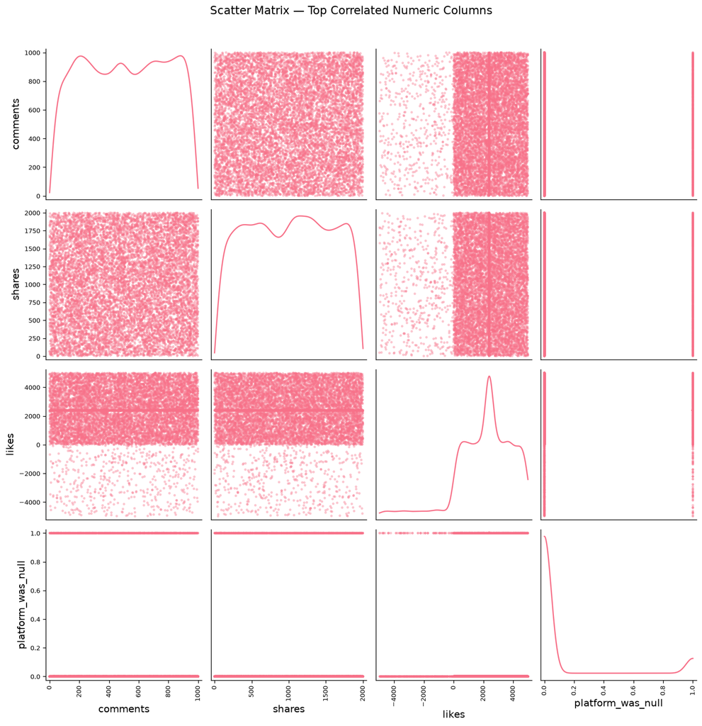

```python
def scatter_matrix_top_correlated(df: pd.DataFrame, top_n: int = 4) -> None:
    """
    Plots a scatter matrix for the top-N most correlated numeric columns.

    This surfaces non-linear or cluster patterns that the linear
    correlation heatmap cannot capture.

    Parameters
    ----------
    df : pd.DataFrame
    top_n : int
        Number of columns to include.

    Returns
    -------
    None
    """
    numeric_df = df.select_dtypes(include='number').dropna()
    if numeric_df.shape[1] < 2:
        print('Insufficient numeric columns for scatter matrix.')
        return

    corr = numeric_df.corr().abs()
    np.fill_diagonal(corr.values, 0)
    top_cols = corr.mean().nlargest(min(top_n, len(corr))).index.tolist()

    pd.plotting.scatter_matrix(
        numeric_df[top_cols], figsize=(3 * len(top_cols), 3 * len(top_cols)),
        diagonal='kde', alpha=0.4, color=PALETTE[0]
    )
    plt.suptitle('Scatter Matrix — Top Correlated Numeric Columns', y=1.02, fontsize=14)
    plt.tight_layout()
    plt.savefig(os.path.join('reports', 'scatter_matrix.png'), bbox_inches='tight')
    plt.show()


scatter_matrix_top_correlated(df)
```

**Interpretation**: The scatter matrix plots every selected variable against every other. Diagonal cells show the kernel density estimate of each variable in isolation. Off-diagonal cells reveal the pairwise relationship: a tight diagonal band indicates a strong linear relationship; a funnel shape indicates heteroscedasticity (variance growing with the mean); and a point cloud with no structure indicates no relationship. Curved or crescent-shaped patterns are signs of non-linear relationships that linear correlation coefficients would underreport.

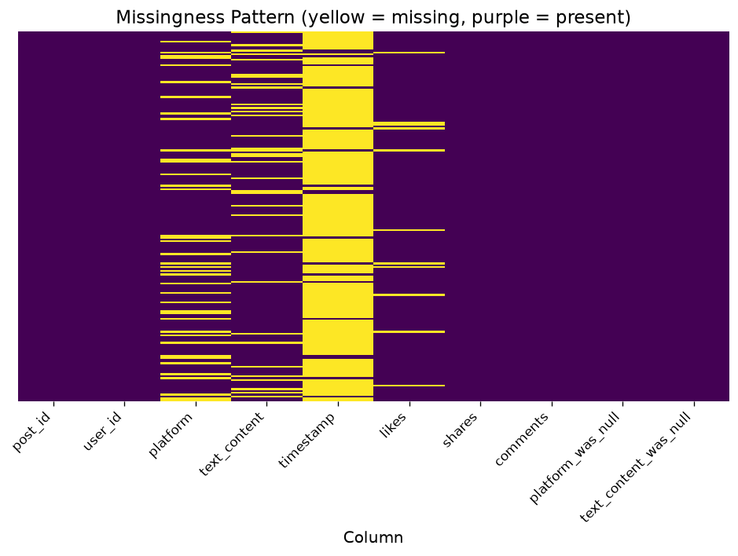

```python
def missing_pattern_heatmap(df: pd.DataFrame) -> None:
    """
    Visualises the missingness pattern across columns as a heatmap.

    Rows with any missing values are shown; yellow = missing, purple = present.
    This reveals whether missingness is random (MCAR) or systematic (MAR/MNAR).

    Parameters
    ----------
    df : pd.DataFrame

    Returns
    -------
    None
    """
    null_df = df.isnull()
    if not null_df.any().any():
        print('No missing values remain in the cleaned dataset — MCAR/MAR analysis skipped.')
        return

    # Show only rows with at least one null
    has_null = null_df.any(axis=1)
    sample_df = null_df[has_null].sample(min(200, has_null.sum()), random_state=RANDOM_SEED)

    fig, ax = plt.subplots(figsize=(min(14, df.shape[1] * 0.8), 6))
    sns.heatmap(sample_df, cmap='viridis', cbar=False, ax=ax, yticklabels=False)
    ax.set_title('Missingness Pattern (yellow = missing, purple = present)')
    ax.set_xlabel('Column')
    plt.xticks(rotation=45, ha='right')
    plt.tight_layout()
    plt.savefig(os.path.join('reports', 'missingness_pattern.png'), bbox_inches='tight')
    plt.show()


missing_pattern_heatmap(df)
```

**Interpretation**: If the yellow (missing) blocks are randomly scattered across the heatmap, missingness is likely *Missing Completely At Random* (MCAR) — the safest assumption for imputation. If missing values in one column consistently co-occur with missing values in another, this is *Missing At Random* (MAR) — meaning there is a systematic mechanism creating the gaps. If missing values cluster in specific row ranges, this may indicate *Missing Not At Random* (MNAR) — where the absence of data itself carries meaning (e.g., respondents skipping sensitive income questions).

## 9. Before / After Profiling Comparison

See `docs/profiling_comparison.md` for the full before/after comparison.

Key evidence of cleaning quality:

[output not shown]

- Raw profile report: `reports/raw_profile.html`
- Cleaned profile report: `reports/cleaned_profile.html`